# K-Means and Hierarchical Clustering

For DATA50XX by ctong

## Overview

### What is Clustering?

**Clustering** is an unsupervised learning technique used to group similar data points together based on their features. Clustering does **not** use predefined labels. Unlike supervised classification, clustering is not a method to predict existing class labels in a data set. Instead, the algorithm “detects” groupings on its own.

**Goal:** Partition data into groups (“clusters”) so that items in the same group are more similar to each other than to those in other groups.

### Sample Use Cases

**Customer Segmentation:**

- Identify groups of customers with similar behaviors or demographics.
- Target marketing and promotions to each segment.
- Example: Segment online shoppers by purchase frequency, average spend, or product preference.

**Market Research:**

- Group survey respondents with similar preferences or attitudes.
- Develop targeted products and marketing strategies for each segment.
- Example: Discover groups such as budget-focused buyers, tech enthusiasts, or environmentally conscious consumers.

**Document Categorization:**

- Cluster documents based on word usage or topics.
- Automatically organize articles, support tickets, or research papers.
- Example: Group news stories into categories like politics, sports, and entertainment without predefined labels.

**Image Compression:**

- Reduce the number of colors in an image by grouping similar pixel colors (color quantization).
- Achieve smaller file sizes while maintaining visual quality.
- Example: Compress an image from millions of colors down to 16 or 32 representative colors for web use.

**Anomaly Detection:**

- Identify patterns of normal behavior as clusters.
- Flag unusual data points that do not fit any cluster (possible anomalies or outliers).
- Example: Detect credit card fraud by finding transactions that are far from all cluster centers.

**Social Network Analysis:**

- Find groups of individuals with similar activity or connection patterns.
- Recommend connections or target content/ads to specific groups.
- Example: Cluster users in an online platform based on the groups they join or the type of content they share.

## k-Means Clustering

### What is k-Means Clustering?

- **k-means** is a popular clustering algorithm that divides data into *k* clusters.
- Each cluster is represented by its **centroid** (the mean of the points in the cluster).

### Algorithm

1. Select the number of clusters, *k*.
2. Randomly assign each data point to a cluster, or initialize cluster centroids randomly.
3. Repeat until convergence (no more changes in cluster assignment):
   - Assign each point to the nearest centroid.
   - Update the centroid of each cluster to be the mean of the points assigned to it.

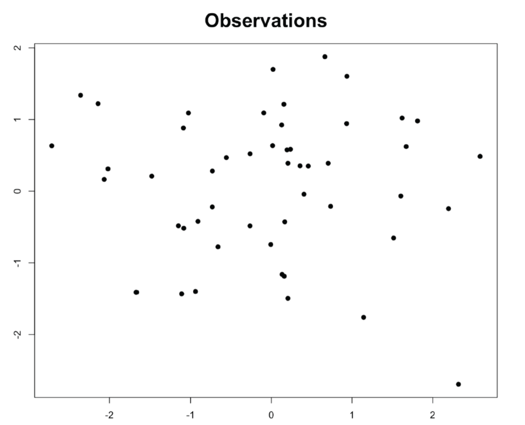

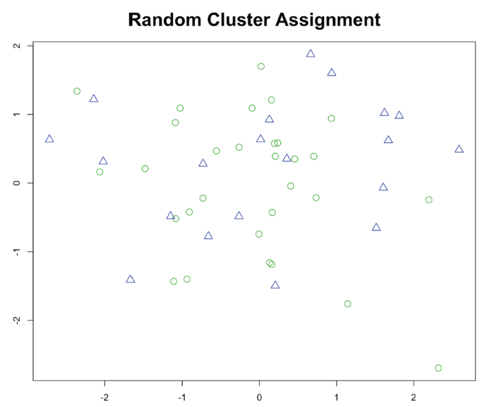

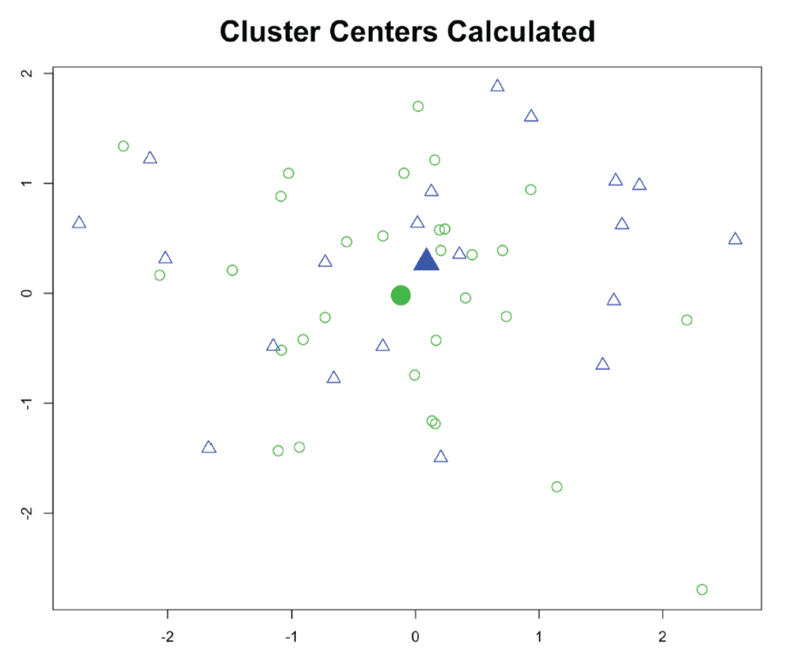

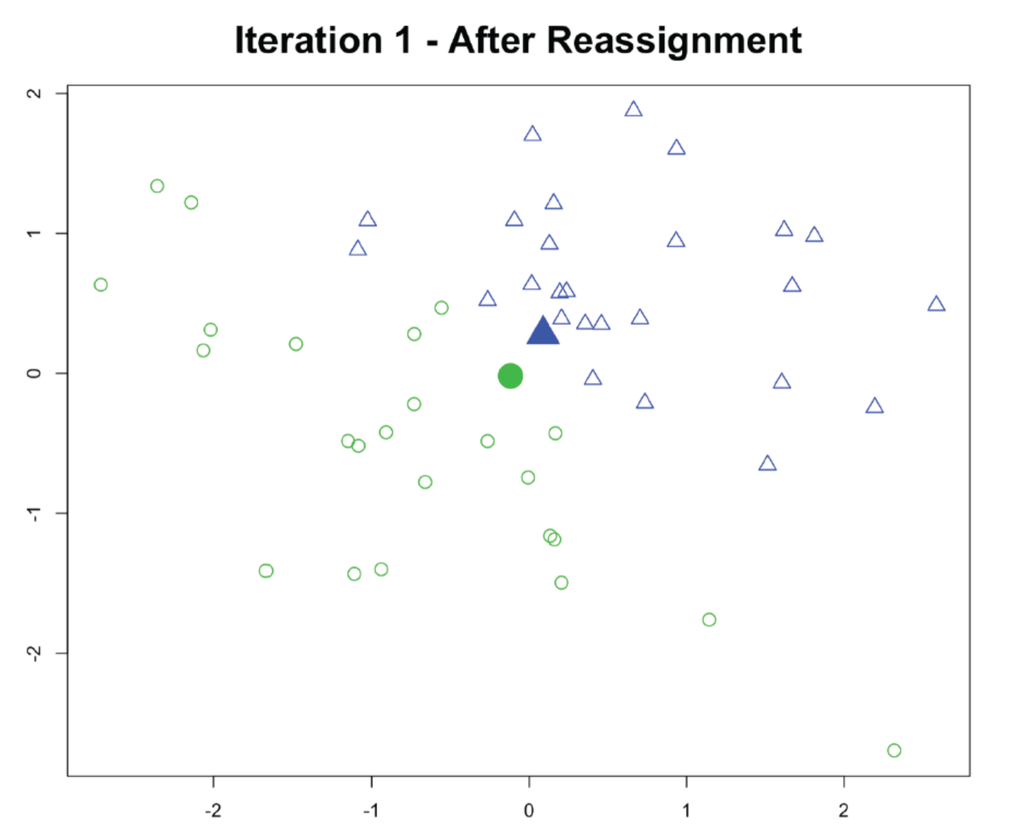

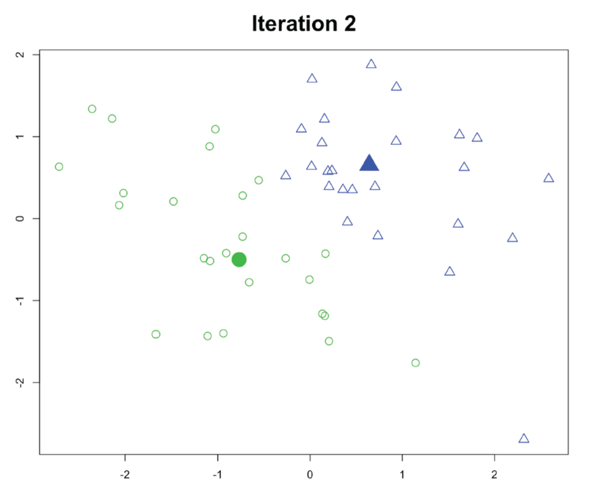

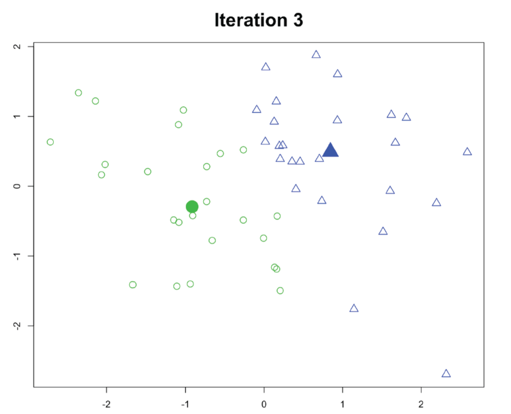

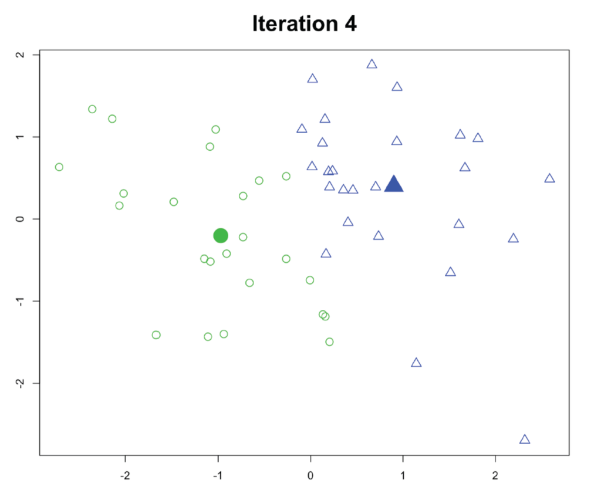

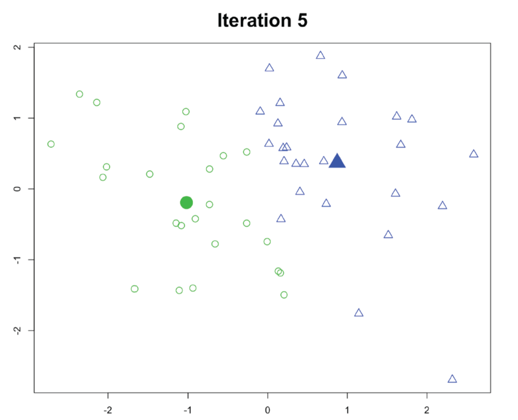

### k-Means Clustering in R

**Data:** `iris` dataset (excluding the species label)

**Task:** Cluster the data into 3 groups (k = 3)

**Function:** `kmeans` with the following arguments

- `centers = 3`: Number of clusters (k)
- `nstart = 25`: Runs the algorithm 25 times with different starting points, keeps the best result with lowest WSS. Within-Cluster Sum of Squares (WSS) measures how tightly grouped the data points are within each cluster. For each cluster, it calculates the sum of the squared distances between each point and its assigned cluster centroid. The total WSS is the sum of these values for all clusters. Lower WSS means the clusters are more compact.

```r
data(iris)
iris_num <- iris[, 1:4] # remove species labels
iris_scaled <- scale(iris_num)  # Standardize each feature to mean 0, sd = 1

set.seed(123)  # for reproducibility
km <- kmeans(iris_scaled, centers = 3, nstart = 25)
str(km)
```

```
## List of 9
##  $ cluster     : int [1:150] 1 1 1 1 1 1 1 1 1 1 ...
##  $ centers     : num [1:3, 1:4] -1.0112 -0.0501 1.1322 0.8504 -0.8804 ...
##   ..- attr(*, "dimnames")=List of 2
##   .. ..$ : chr [1:3] "1" "2" "3"
##   .. ..$ : chr [1:4] "Sepal.Length" "Sepal.Width" "Petal.Length" "Petal.Width"
##  $ totss       : num 596
##  $ withinss    : num [1:3] 47.4 44.1 47.5
##  $ tot.withinss: num 139
##  $ betweenss   : num 457
##  $ size        : int [1:3] 50 53 47
##  $ iter        : int 2
##  $ ifault      : int 0
##  - attr(*, "class")= chr "kmeans"
```

```r
km$cluster   # Cluster assignment for each observation
```

```
##   [1] 1 1 1 1 1 1 1 1 1 1 1 1 1 1 1 1 1 1 1 1 1 1 1 1 1 1 1 1 1 1 1 1 1 1 1 1 1
##  [38] 1 1 1 1 1 1 1 1 1 1 1 1 1 3 3 3 2 2 2 3 2 2 2 2 2 2 2 2 3 2 2 2 2 3 2 2 2
##  [75] 2 3 3 3 2 2 2 2 2 2 2 3 3 2 2 2 2 2 2 2 2 2 2 2 2 2 3 2 3 3 3 3 2 3 3 3 3
## [112] 3 3 2 2 3 3 3 3 2 3 2 3 2 3 3 2 3 3 3 3 3 3 2 2 3 3 3 2 3 3 3 2 3 3 3 2 3
## [149] 3 2
```

```r
km$centers   # Cluster centers (centroids)
```

```
##   Sepal.Length Sepal.Width Petal.Length Petal.Width
## 1  -1.01119138  0.85041372   -1.3006301  -1.2507035
## 2  -0.05005221 -0.88042696    0.3465767   0.2805873
## 3   1.13217737  0.08812645    0.9928284   1.0141287
```

```r
table(km$cluster)
```

```
##
##  1  2  3
## 50 53 47
```

### Visualizing the Clusters

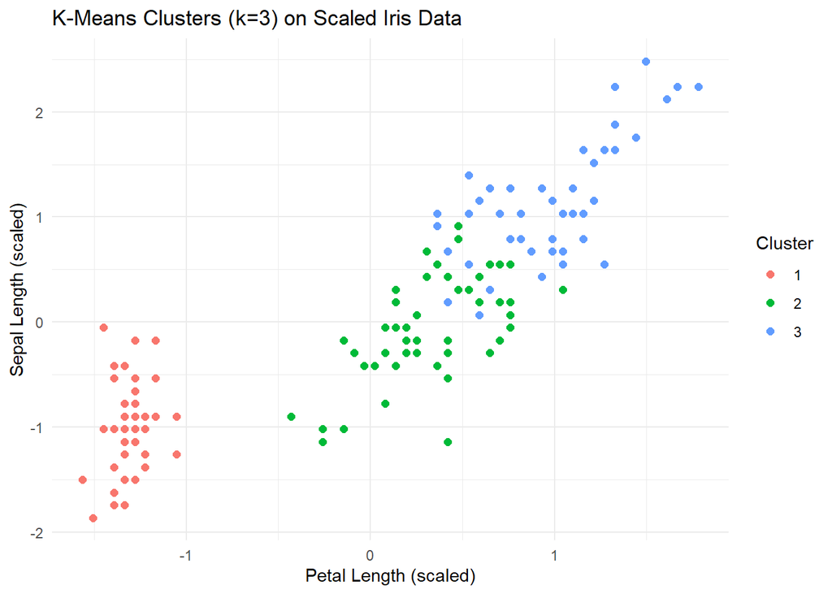

```r
library(dplyr)
library(ggplot2)

# Visualize clusters using two original features
# Petal.Length and Sepal.Length (you can try other pairs)

iris_clustered <- as.data.frame(iris_scaled) %>%
  mutate(Cluster = as.factor(km$cluster))

ggplot(iris_clustered, aes(x = Petal.Length, y = Sepal.Length, color = Cluster)) +
  geom_point(size = 2) +
  labs(title = "K-Means Clusters (k=3) on Scaled Iris Data",
       x = "Petal Length (scaled)", y = "Sepal Length (scaled)") +
  theme_minimal()
```

### Choosing the Number of Clusters (k)

The “right” value of *k* is not always obvious, use the **Elbow Method** – try different values of k and plot WSS against K, then low for the “elbow” point where the decrease in WSS “slows down”

When you increase the number of clusters (*k*), WSS will decrease, because each cluster has fewer points, so they can be grouped more tightly. However, after a certain point, the improvement becomes marginal—the “elbow” point—which can be used to select a suitable *k*.

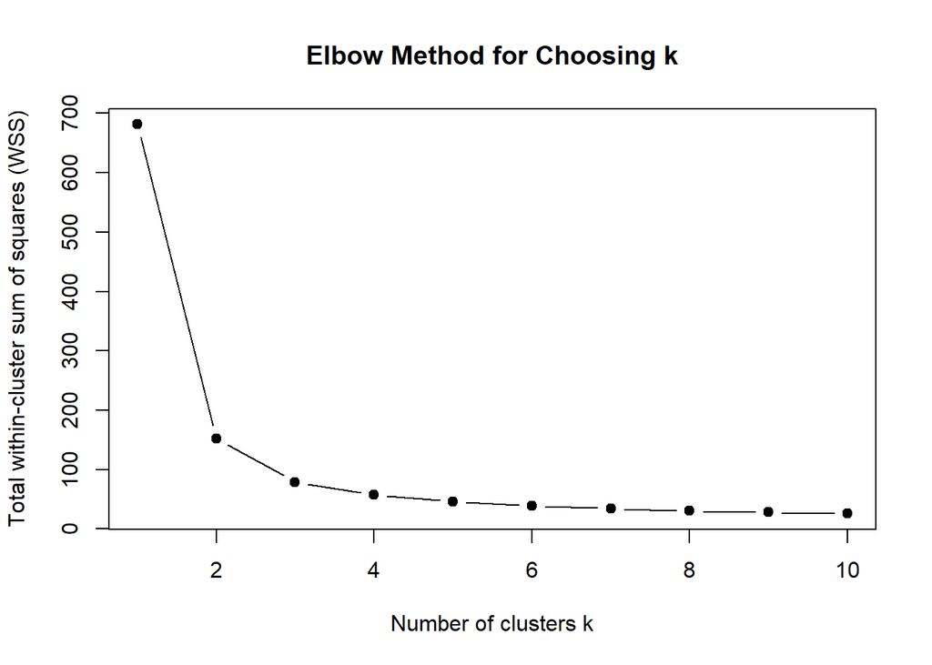

```r
wss <- numeric(10)
for (k in 1:10) {
  wss[k] <- kmeans(iris_num, centers = k, nstart = 10)$tot.withinss
}
plot(1:10, wss, type = "b", pch = 19,
     xlab = "Number of clusters k",
     ylab = "Total within-cluster sum of squares (WSS)",
     main = "Elbow Method for Choosing k")
```

### Considerations and Limitations

**No inherent meaning for cluster labels**

Observations may be assigned to different class labels in identical solutions.

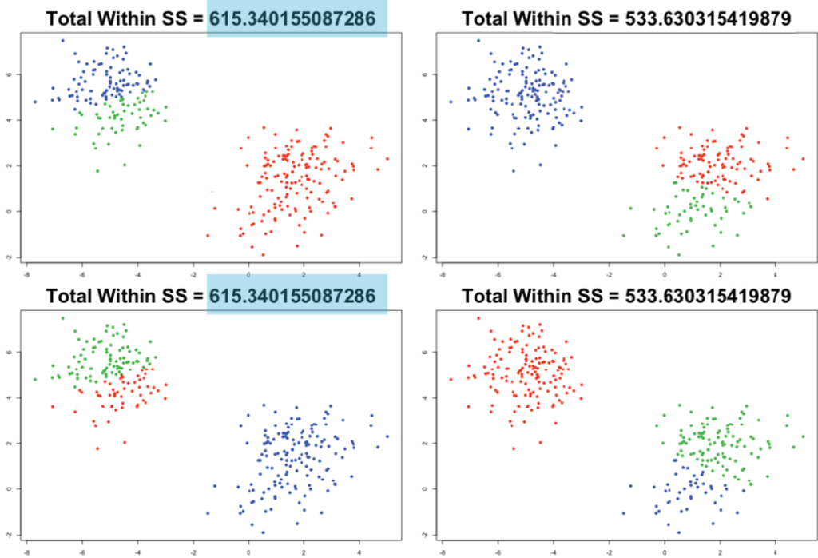

**Sensitive to scale**

K-means relies on distance calculations, so features with larger ranges can dominate the clustering outcome.  
*Solution:* Always **standardize or normalize your variables** (e.g., using `scale()` in R) so each feature contributes equally.

**Sensitive to outliers**

Outliers can pull cluster centroids toward them, distorting cluster assignments.  
*Solution:* Consider **removing outliers** prior to clustering, or use more robust clustering methods (e.g., k-medoids or DBSCAN - not covered in this course) when outliers are expected.

**Assumes clusters are spherical and equally sized**

K-means tends to partition data into clusters of similar size and shape, which may not reflect real data structures.  
*Solution:* Explore your data visually before clustering; if clusters are not spherical/equally sized, consider using **other clustering algorithms** (such as hierarchical clustering).

**Random initialization**

The algorithm can converge to different solutions depending on initial centroid positions, sometimes resulting in suboptimal clustering.  
*Solutions:* Use the `nstart` parameter to **run k-means multiple times** with different random initializations and select the best result (lowest WSS). For most datasets, setting `nstart = 25` is typical and generally sufficient; for large or critical datasets, use `nstart = 50` or `100`. You can also consider enhanced methods for selecting initial cluster centers. **k-means++** is one such option. It uses a probability based algorithm to encourage initial cluster centers to spread out away from each other.

### Summary

- K-means clustering is a simple and widely used method to group data.
- Choosing the right *k* is part of the analysis process.
- Always visualize and assess the quality of the clusters.

## Hierarchical Clustering

### What is Hierarchical Clustering?

Hierarchical clustering is an unsupervised machine learning method used to group similar data points into clusters by building a tree-like structure (known as a dendrogram) based on similarity between data points. There are two approaches to perform hierarchical clustering:

- **Agglomerative (Bottom-up)**: Each observation starts in its own cluster, and pairs of clusters are merged as one moves up the hierarchy.
- **Divisive (Top-down)**: All observations start in one cluster, and splits are performed recursively as one moves down the hierarchy.

The agglomerative (bottom-up) approach is more commonly used, so it will be the focus of this lesson.

### Algorithm

1. Begin with each observation in its own cluster.
2. Calculate the distance (similarity) between each pair of clusters using the chosen linkage method (see below).
3. Link the closest pair of clusters to form a new cluster.
4. Repeat until all observations are in a single cluster.
5. Display the results as a dendrogram, which shows the order of cluster merges and the distances between the merged clusters on the vertical axis.

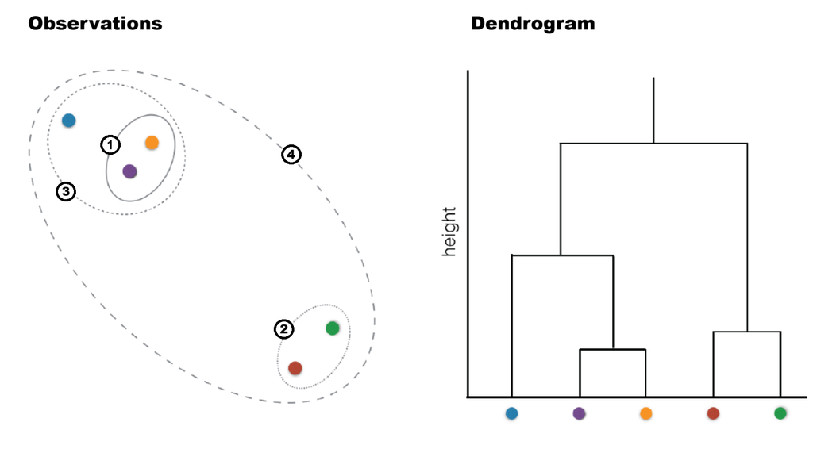

6. Finalize cluster assignment either by specifying a fixed number of clusters or setting a height threshold on the dendrogram.

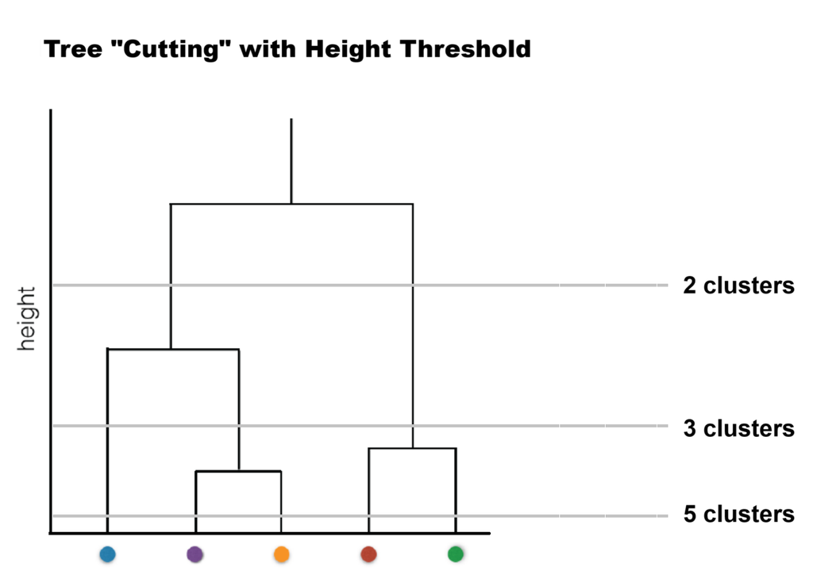

### Linkage Methods

The linkage method determines how the distance between clusters is calculated:

- **Single linkage**: Distance between the closest pair of points in the two clusters.
- **Complete linkage**: Distance between the farthest pair of points in the two clusters.
- **Average linkage**: Average distance between all pairs of points in the two clusters.
- **Centroid method**: Distance between the centroids of the two clusters. Centroid coordinates are computed as the arithmetic mean of the coordinates for the points in a cluster.

For most practical applications where you want well-separated, compact clusters, *complete* or *average* linkage is preferred.

| Linkage | Shape of Clusters | Sensitive to Outliers | Tendency | Use When… |
| --- | --- | --- | --- | --- |
| Complete | Compact, spherical | Yes | Avoid chaining | Clusters should be tight |
| Average | Moderate | Somewhat | Compromise | Balance between chaining and compactness |
| Single | Irregular, elongated | No | Chaining | Clusters can be long or “chain-like” |
| Centroid | Center-based, varied | Yes | Inversions | Not commonly used due to potential for inversions, i.e., clusters meerge at a lower distance than their constituents, which reduce interpretability. |

### Hierarchical Clustering in R

**Data:** `iris` dataset (excluding the species label)

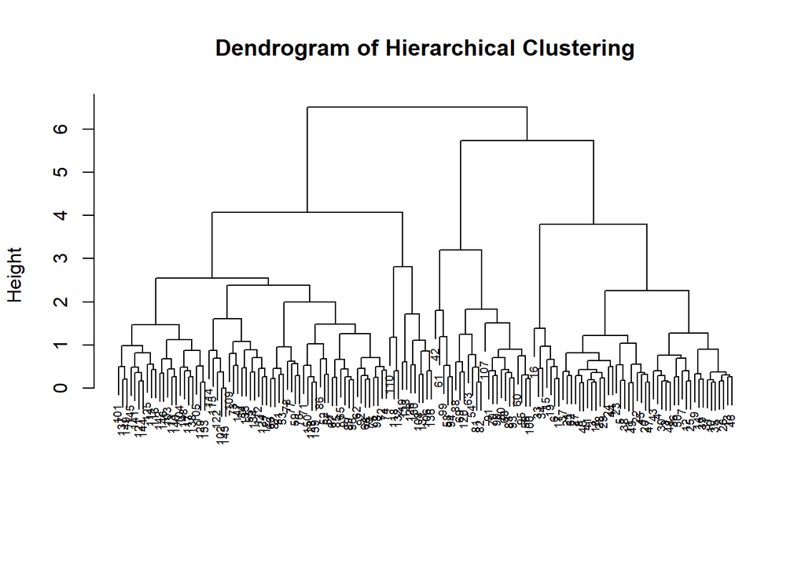

```r
library(ggplot2)
data(iris)
iris_num <- iris[, 1:4] # remove species labels
iris_scaled <- scale(iris_num)  # Standardize each feature to mean 0, sd 1

# Compute the Euclidean distance matrix
dist_matrix <- dist(iris_scaled, method = "euclidean")

# Perform hierarchical clustering with complete linkage
hc_complete <- hclust(dist_matrix, method = "complete")

# Plot the dendrogram
plot(hc_complete, main = "Dendrogram of Hierarchical Clustering",
     xlab = "", sub = "", cex = 0.6)
```

```r
# Cut the tree into desired number of clusters (set value for k)
clusters <- cutree(hc_complete, k = 3) # 3 clusters

# Alternatively, cut the tree by setting a height threshold (h)
# e.g., cutree(hc_complete, h = 3.5)

# View cluster assignment
table(clusters)
```

```
## clusters
##  1  2  3
## 49 24 77
```

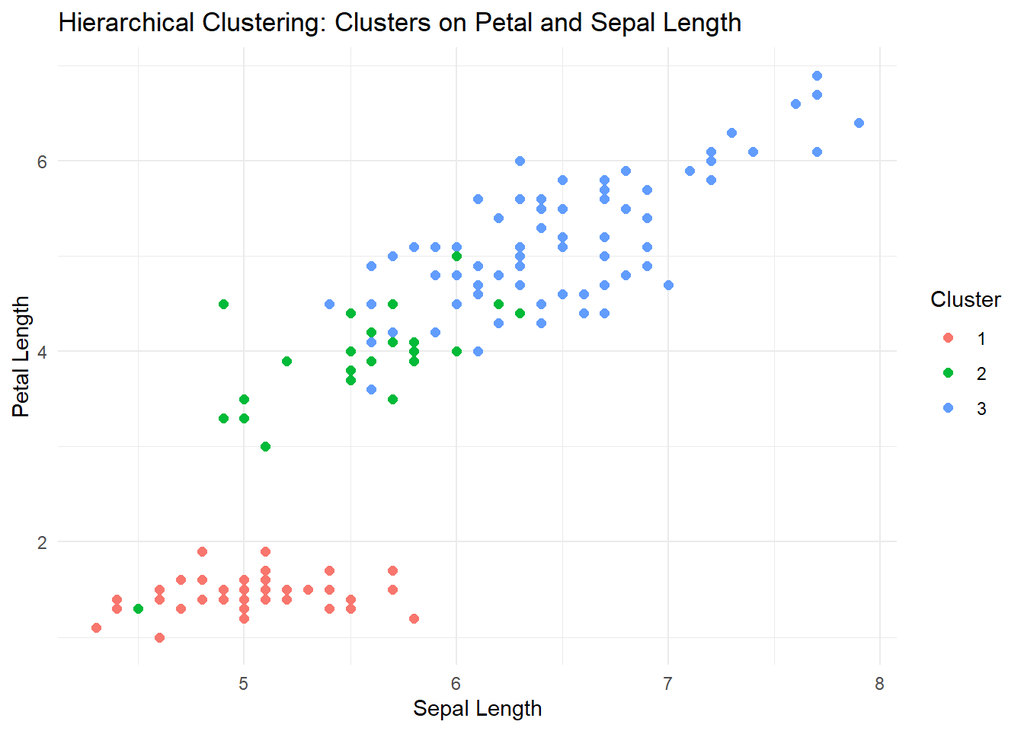

```r
# Add cluster assignments to the scaled data for visualization
iris_clustered <- data.frame(iris_scaled, Cluster = as.factor(clusters))

# For plotting, retrieve the original scale for Petal.Length and Sepal.Length
iris_plot <- data.frame(
  Sepal.Length = iris$Sepal.Length,
  Petal.Length = iris$Petal.Length,
  Cluster = as.factor(clusters)
)

ggplot(iris_plot, aes(x = Sepal.Length, y = Petal.Length, color = Cluster)) +
  geom_point(size = 2) +
  labs(
    title = "Hierarchical Clustering: Clusters on Petal and Sepal Length",
    x = "Sepal Length",
    y = "Petal Length"
  ) +
  theme_minimal()
```

### Considerations and Limitations

**Computationally expensive**

Calculating the distance (similarity) between each pair of clusters is computationally demanding, especially for large datasets.

**Sensitive to scale**

Features with larger ranges can dominate the clustering outcome.  
*Solution:* Always **standardize or normalize your variables** (e.g., using `scale()` in R) so each feature contributes equally.

**Sensitive to outliers**

Outliers can distort cluster assignment.  
*Solution:* Consider **removing outliers** prior to clustering, or use more robust clustering methods (e.g., k-medoids or DBSCAN - not covered in this course) when outliers are expected.

### Summary

- Hierarchical clustering is a powerful unsupervised learning technique for grouping similar observations.
- It builds a hierarchy of clusters without requiring the number of clusters in advance.
- The choice of distance metric and linkage method affects the results.
- Dendrograms provide a useful way to visualize relationships between clusters.